# tidyr and ggplot2 Tutorial Answers

Chantal Koechli

1/28/2018

```r
#loading the libraries we'll be using
library(tidyr)
library(dplyr)
library(ggplot2 )
```

#### Answers to the “On your Own” component of the tidyr and ggplot2 tutorials

### tidyr Answers

1. Daily Show dataset is tidy because it fits the criteria for being tidy:
- Each variable has its own column - no sharing of columns.
- Each observation (in this case, guest on the show) has its own row
- Values of variables are stored in cells, not column headers (ex. the year of the show is shown in a cell, not in a header like “guests_2011”)
- No units are included in the dataset
- No extraneous information is included in the dataset
2. The under5mortality dataset is not tidy because the year columns contain values that detail mortality rate. Thus, two variables (year and mortality) are contained within one column and the variable Year is stored in a column header, not a cell. To change the dataset into a tidy dataset, you would need to create a separate year column, containing all the year values, and a mortality rate column, containing the mortality rate values. For instance:

```r
#reading in file
under5 = read.csv("Desktop/under5mortality.csv")
head(under5) # I always check out the dataset to see what column names are, etc
```

```
##                 Country  X1800  X1801  X1802  X1803  X1804  X1805  X1806
## 1              Abkhazia     NA     NA     NA     NA     NA     NA     NA
## 2           Afghanistan 468.58 468.58 468.58 468.58 468.58 468.58 469.98
## 3 Akrotiri and Dhekelia     NA     NA     NA     NA     NA     NA     NA
## 4               Albania 375.20 375.20 375.20 375.20 375.20 375.20 375.20
## 5               Algeria 460.21 460.21 460.21 460.21 460.21 460.21 460.21
## 6        American Samoa     NA     NA     NA     NA     NA     NA     NA
##    X1807  X1808  X1809  X1810  X1811  X1812  X1813  X1814  X1815  X1816
## 1     NA     NA     NA     NA     NA     NA     NA     NA     NA     NA
## 2 469.98 469.98 469.98 469.98 469.98 469.98 469.98 469.98 469.98 471.38
## 3     NA     NA     NA     NA     NA     NA     NA     NA     NA     NA
## 4 375.20 375.20 375.20 375.20 375.20 375.20 375.20 375.20 375.20 375.20
## 5 460.21 460.21 460.21 460.21 460.21 460.21 460.21 460.21 460.21 460.21
## 6     NA     NA     NA     NA     NA     NA     NA     NA     NA     NA
##    X1817  X1818  X1819  X1820  X1821  X1822  X1823  X1824  X1825  X1826
```

[output cut: 139 more lines]

```r
#Creating a tidy dataset, by creating separate year and mortality rate columns
under5_tidy = gather(under5, year, mortality, X1800:X2015)
#Looking at output
head(under5_tidy)
```

```
##                 Country  year mortality
## 1              Abkhazia X1800        NA
## 2           Afghanistan X1800    468.58
## 3 Akrotiri and Dhekelia X1800        NA
## 4               Albania X1800    375.20
## 5               Algeria X1800    460.21
## 6        American Samoa X1800        NA
```

```r
#The dataset read in with Xs attached to the year - this may signifiy that a space character is present before each year. We can use extract_numeric to extract only the number values.
under5_tidy$year = extract_numeric(under5_tidy$year)
#Looking at output
head(under5_tidy)
```

```
##                 Country year mortality
## 1              Abkhazia 1800        NA
## 2           Afghanistan 1800    468.58
## 3 Akrotiri and Dhekelia 1800        NA
## 4               Albania 1800    375.20
## 5               Algeria 1800    460.21
## 6        American Samoa 1800        NA
```

3. mlb2016 is not a tidy dataset because the date column contains both beginning and ending years of the salary contract, as well as the duration of the contract. Also, units (dollar signs) are found in the `Salary`, `Total.Value`, and `Avg. Annual` columns. To change this into a tidy dataset, the `Years` column would need to be split into three columns : Begin, End, and Duration and the dollar signs would need to be removed :

```r
#reading in dataset
mlb = read.csv("Desktop/mlb2016.csv")
#taking a look at the dataset
head(mlb)
```

```
##               Name Team POS       Salary        Years   Total.Value
## 1  Clayton Kershaw  LAD  SP $33,000,000   7 (2014-20) $215,000,000
## 2     Zack Greinke  ARI  SP $31,799,030   6 (2016-21) $206,500,000
## 3      David Price  BOS  SP $30,000,000   7 (2016-22) $217,000,000
## 4   Miguel Cabrera  DET  1B $28,000,000  10 (2014-23) $292,000,000
## 5 Justin Verlander  DET  SP $28,000,000   7 (2013-19) $180,000,000
## 6  Yoenis Cespedes  NYM  CF $27,328,046   3 (2016-18)  $75,000,000
##     Avg.Annual
## 1 $30,714,286
## 2 $34,416,666
## 3 $31,000,000
## 4 $29,200,000
## 5 $25,714,285
## 6 $25,000,000
```

```r
#Separating Years column
mlb_tidy = separate(mlb, Years, c("Duration", "Beginning", "End"))
#looking at dataset
head(mlb_tidy)
```

```
##               Name Team POS       Salary Duration Beginning End
## 1  Clayton Kershaw  LAD  SP $33,000,000         7      2014  20
## 2     Zack Greinke  ARI  SP $31,799,030         6      2016  21
## 3      David Price  BOS  SP $30,000,000         7      2016  22
## 4   Miguel Cabrera  DET  1B $28,000,000        10      2014  23
## 5 Justin Verlander  DET  SP $28,000,000         7      2013  19
## 6  Yoenis Cespedes  NYM  CF $27,328,046         3      2016  18
##     Total.Value   Avg.Annual
## 1 $215,000,000  $30,714,286
## 2 $206,500,000  $34,416,666
## 3 $217,000,000  $31,000,000
## 4 $292,000,000  $29,200,000
## 5 $180,000,000  $25,714,285
## 6  $75,000,000  $25,000,000
```

```r
#hmmm...let's say we want the ending year to be expressed as 2020 instead of 20. Let's use the useful `paste` function:
mlb_tidy$End = paste(20, mlb_tidy$End, sep = "")

#Removing dollar signs
mlb_tidy$Salary = extract_numeric(mlb_tidy$Salary)
mlb_tidy$Total.Value = extract_numeric(mlb_tidy$Total.Value)
mlb_tidy$Avg.Annual = extract_numeric(mlb_tidy$Avg.Annual)
#Looking at results
head(mlb_tidy)
```

```
##               Name Team POS   Salary Duration Beginning  End Total.Value
## 1  Clayton Kershaw  LAD  SP 33000000        7      2014 2020   215000000
## 2     Zack Greinke  ARI  SP 31799030        6      2016 2021   206500000
## 3      David Price  BOS  SP 30000000        7      2016 2022   217000000
## 4   Miguel Cabrera  DET  1B 28000000       10      2014 2023   292000000
## 5 Justin Verlander  DET  SP 28000000        7      2013 2019   180000000
## 6  Yoenis Cespedes  NYM  CF 27328046        3      2016 2018    75000000
##   Avg.Annual
## 1   30714286
## 2   34416666
## 3   31000000
## 4   29200000
## 5   25714285
## 6   25000000
```

4. USBprices2 is not tidy because each row contains three observations of data (from 2009 and 2003 AND across different food types). Additionally, each column contains the variable of date in addition to the food type. To tidy up this data, we need to create a column designating type of food, a column designating year, and a column designating price of each food item for each specific year. However, we will need to do this stepwise, first using gather to create a column with food type and year and a column with price. Then, we can separate the food type - year column into separate columns :

```r
#reading in dataset
ubs2 = read.csv("Desktop/UBSprices2.csv")
#looking at dataset
head(ubs2)
```

```
##        city bigmac2009 bread2009 rice2009 bigmac2003 bread2003 rice2003
## 1 Amsterdam         19        10       11         16         9        9
## 2    Athens         30        13       27         21        12       19
## 3  Auckland         19        19       13         19        19        9
## 4   Bangkok         45        43       27         50        42       25
## 5 Barcelona         21        17        8         22        19       10
## 6    Berlin         19        10       17         16        10       16
```

```r
#gathering data to create
ubs2_tidy = gather(ubs2, FoodYear, Price, bigmac2009:rice2003)
#looking at output
head(ubs2_tidy)
```

```
##        city   FoodYear Price
## 1 Amsterdam bigmac2009    19
## 2    Athens bigmac2009    30
## 3  Auckland bigmac2009    19
## 4   Bangkok bigmac2009    45
## 5 Barcelona bigmac2009    21
## 6    Berlin bigmac2009    19
```

```r
#Separating Food type and year. Note that the sep = -5 parameter indicates that the separation between the FoodYear variable should occur between the fourth and fifth character from the right.
ubs2_tidy = separate(ubs2_tidy, FoodYear, c("Food", "Year"), sep = -5)
#Looking at output
head(ubs2_tidy)
```

```
##        city   Food Year Price
## 1 Amsterdam bigmac 2009    19
## 2    Athens bigmac 2009    30
## 3  Auckland bigmac 2009    19
## 4   Bangkok bigmac 2009    45
## 5 Barcelona bigmac 2009    21
## 6    Berlin bigmac 2009    19
```

### ggplot2 Tutorial Answers

- **Restrict the AmesHousing data to only sales under normal conditions. In other words, Condition.1 == Norm**

```r
#reading in dataset
AmesHousing = read.csv("Desktop/AmesHousing.csv")
#looking at dataset
head(AmesHousing)
```

```
##   Order       PID MS.SubClass MS.Zoning Lot.Frontage Lot.Area Street Alley
## 1     1 526301100          20        RL          141    31770   Pave  <NA>
## 2     2 526350040          20        RH           80    11622   Pave  <NA>
## 3     3 526351010          20        RL           81    14267   Pave  <NA>
## 4     4 526353030          20        RL           93    11160   Pave  <NA>
## 5     5 527105010          60        RL           74    13830   Pave  <NA>
## 6     6 527105030          60        RL           78     9978   Pave  <NA>
##   Lot.Shape Land.Contour Utilities Lot.Config Land.Slope Neighborhood
## 1       IR1          Lvl    AllPub     Corner        Gtl        NAmes
## 2       Reg          Lvl    AllPub     Inside        Gtl        NAmes
## 3       IR1          Lvl    AllPub     Corner        Gtl        NAmes
## 4       Reg          Lvl    AllPub     Corner        Gtl        NAmes
## 5       IR1          Lvl    AllPub     Inside        Gtl      Gilbert
## 6       IR1          Lvl    AllPub     Inside        Gtl      Gilbert
##   Condition.1 Condition.2 Bldg.Type House.Style Overall.Qual Overall.Cond
```

[output cut: 90 more lines]

```r
#filtering to Condition.1 == Norm
AmesHousing_filt = filter(AmesHousing, Condition.1 == "Norm")
#looking at output
head(AmesHousing_filt$Condition.1)
```

```
## [1] Norm Norm Norm Norm Norm Norm
## Levels: Artery Feedr Norm PosA PosN RRAe RRAn RRNe RRNn
```

- **Create a new variable called TotalSqFt = GR.Liv.Area + Total.Bsmt.SF and remove any homes with more than 3000 total square feet.**

```r
#Using %>% to chain together the two commands - mutate and filter
AH_filt_totsqft = mutate(AmesHousing_filt, TotalSqFt = Gr.Liv.Area + Total.Bsmt.SF) %>% filter(TotalSqFt <= 3000)

#looking at output
head(AH_filt_totsqft)
```

```
##   Order       PID MS.SubClass MS.Zoning Lot.Frontage Lot.Area Street Alley
## 1     1 526301100          20        RL          141    31770   Pave  <NA>
## 2     3 526351010          20        RL           81    14267   Pave  <NA>
## 3     5 527105010          60        RL           74    13830   Pave  <NA>
## 4     6 527105030          60        RL           78     9978   Pave  <NA>
## 5     7 527127150         120        RL           41     4920   Pave  <NA>
## 6     8 527145080         120        RL           43     5005   Pave  <NA>
##   Lot.Shape Land.Contour Utilities Lot.Config Land.Slope Neighborhood
## 1       IR1          Lvl    AllPub     Corner        Gtl        NAmes
## 2       IR1          Lvl    AllPub     Corner        Gtl        NAmes
## 3       IR1          Lvl    AllPub     Inside        Gtl      Gilbert
## 4       IR1          Lvl    AllPub     Inside        Gtl      Gilbert
## 5       Reg          Lvl    AllPub     Inside        Gtl      StoneBr
## 6       IR1          HLS    AllPub     Inside        Gtl      StoneBr
##   Condition.1 Condition.2 Bldg.Type House.Style Overall.Qual Overall.Cond
```

[output cut: 90 more lines]

```r
max(AH_filt_totsqft$TotalSqFt) #shows the maximum value of variable TotalSqFt
```

```
## [1] 3000
```

- **Create a new variable, where No indicates no fireplaces in the home and Yes indicates at least one fireplace in the home.**

This is a bit trickier than the activities you completed in the dplyr tutorial. You will be doing conditional mutating here - that is, the value of a new variable is dependent on the condition (value) of an existing variable.

To do this, the if_else function is used. The if_else function has 3 required parameters : condition, true, and false.

- Condition - the conditional statement used for evaluation. For the code below, I’ve chosen to evaluate the statement that Fireplaces == 0 (a house has 0 fireplaces)
- True - what to put into the new column if the condition is true (in this case, “No”)
- False - what to put into the new column if the condition is false (in this case, “Yes”)

```r
AH_filt_totsqft = mutate(AH_filt_totsqft, FP = if_else(Fireplaces == 0, "No", "Yes"))
```

Note that this conditional mutating could be done in other ways (ex. evaluating the statement that Fireplaces > 0, etc.)

- **With this modified data file, create a graphic involving no more than three explanatory variables that best portrays how to predict sales price. For example, Figure 12 uses a linear model of kitchen quality, above ground square footage, and number of fireplaces to predict sale price.**

There are many possible answers for this (depending on the three variables you use). Here’s an example :

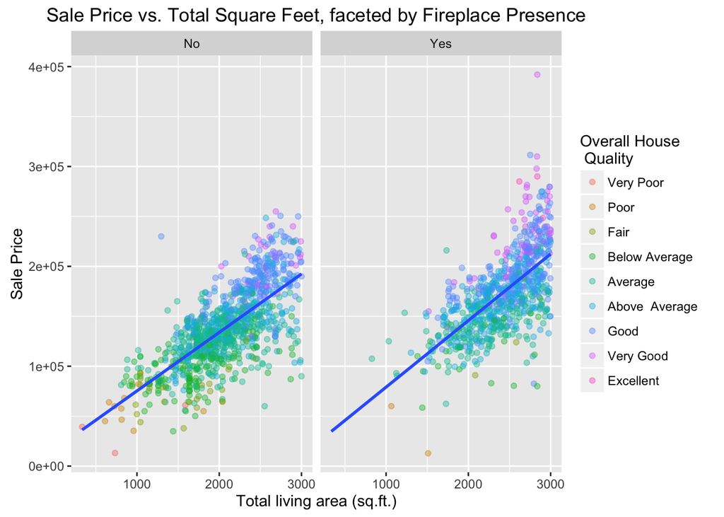

```r
ggplot(AH_filt_totsqft, aes(x = TotalSqFt , y = SalePrice)) +
  geom_point(aes(color = as.factor(Overall.Qual)), alpha = 0.4) +
  geom_smooth(method=lm, se=FALSE, fullrange=TRUE) +
  facet_wrap(~FP) +
  labs(title = "Sale Price vs. Total Square Feet, faceted by Fireplace Presence", y="Sale Price", x = "Total living area (sq.ft.)", color = "Overall House \n Quality") +
  scale_color_discrete(labels = c("Very Poor", "Poor", "Fair", "Below Average", "Average", "Above  Average", "Good", "Very Good", "Excellent"))
```

This plot is showing us that sale price increases with total living area and seems to also increase with overall house quality. The relationship between total living area and sale price does not seem to differ between houses with or without fireplaces, but we do notice that there seem to be a higher number of “below average”, “fair”, and “poor” houses in the set of houses that contain no fireplaces. However, to more firmly establish that relationship, we’d need to explore the data in different ways.